# Visualizing FordGoBike Data

## June 2017- December 2019

### Ahmed M. Hasan

### Dataset URL

[Ford GoBike System Data](https://www.lyft.com/bikes/bay-wheels/system-data)

### Loading and Wrangling

```python
# import all packages
import numpy as np
import pandas as pd
import matplotlib.pyplot as plt
import seaborn as sb
%matplotlib inline
```

```python
# Import 2017 data
df_2017 = pd.read_csv('2017-fordgobike-tripdata.csv')
```

```python
# Showing the first five rows
df_2017.head()
```

|  | duration_sec | start_time | end_time | start_station_id | start_station_name | start_station_latitude | start_station_longitude | end_station_id | end_station_name | end_station_latitude | end_station_longitude | bike_id | user_type |
| --- | --- | --- | --- | --- | --- | --- | --- | --- | --- | --- | --- | --- | --- |
| 0 | 80110 | 2017-12-31 16:57:39.6540 | 2018-01-01 15:12:50.2450 | 74 | Laguna St at Hayes St | 37.776435 | -122.426244 | 43 | San Francisco Public Library (Grove St at Hyde... | 37.778768 | -122.415929 | 96 | Customer |
| 1 | 78800 | 2017-12-31 15:56:34.8420 | 2018-01-01 13:49:55.6170 | 284 | Yerba Buena Center for the Arts (Howard St at ... | 37.784872 | -122.400876 | 96 | Dolores St at 15th St | 37.766210 | -122.426614 | 88 | Customer |
| 2 | 45768 | 2017-12-31 22:45:48.4110 | 2018-01-01 11:28:36.8830 | 245 | Downtown Berkeley BART | 37.870348 | -122.267764 | 245 | Downtown Berkeley BART | 37.870348 | -122.267764 | 1094 | Customer |
| 3 | 62172 | 2017-12-31 17:31:10.6360 | 2018-01-01 10:47:23.5310 | 60 | 8th St at Ringold St | 37.774520 | -122.409449 | 5 | Powell St BART Station (Market St at 5th St) | 37.783899 | -122.408445 | 2831 | Customer |
| 4 | 43603 | 2017-12-31 14:23:14.0010 | 2018-01-01 02:29:57.5710 | 239 | Bancroft Way at Telegraph Ave | 37.868813 | -122.258764 | 247 | Fulton St at Bancroft Way | 37.867789 | -122.265896 | 3167 | Subscriber |

```python
# Look into basic information
df_2017.info(null_counts = True)
```

```
<class 'pandas.core.frame.DataFrame'>
RangeIndex: 519700 entries, 0 to 519699
Data columns (total 13 columns):
duration_sec               519700 non-null int64
start_time                 519700 non-null object
end_time                   519700 non-null object
start_station_id           519700 non-null int64
start_station_name         519700 non-null object
start_station_latitude     519700 non-null float64
start_station_longitude    519700 non-null float64
end_station_id             519700 non-null int64
end_station_name           519700 non-null object
end_station_latitude       519700 non-null float64
end_station_longitude      519700 non-null float64
bike_id                    519700 non-null int64
user_type                  519700 non-null object
dtypes: float64(4), int64(4), object(5)
memory usage: 51.5+ MB
```

```python
# Import 2018 data
df_201801 = pd.read_csv('201801-fordgobike-tripdata.csv')
df_201802 = pd.read_csv('201802-fordgobike-tripdata.csv')
df_201803 = pd.read_csv('201803-fordgobike-tripdata.csv')
df_201804 = pd.read_csv('201804-fordgobike-tripdata.csv')
df_201805 = pd.read_csv('201805-fordgobike-tripdata.csv')
df_201806 = pd.read_csv('201806-fordgobike-tripdata.csv')
df_201807 = pd.read_csv('201807-fordgobike-tripdata.csv')
df_201808 = pd.read_csv('201808-fordgobike-tripdata.csv')
df_201809 = pd.read_csv('201809-fordgobike-tripdata.csv')
df_201810 = pd.read_csv('201810-fordgobike-tripdata.csv')
df_201811 = pd.read_csv('201811-fordgobike-tripdata.csv')
df_201812 = pd.read_csv('201812-fordgobike-tripdata.csv')
```

```python
# Showing the first five rows
df_201801.head()
```

|  | duration_sec | start_time | end_time | start_station_id | start_station_name | start_station_latitude | start_station_longitude | end_station_id | end_station_name | end_station_latitude | end_station_longitude | bike_id | user_type | bike_share_for_all_trip |
| --- | --- | --- | --- | --- | --- | --- | --- | --- | --- | --- | --- | --- | --- | --- |
| 0 | 75284 | 2018-01-31 22:52:35.2390 | 2018-02-01 19:47:19.8240 | 120 | Mission Dolores Park | 37.761420 | -122.426435 | 285 | Webster St at O'Farrell St | 37.783521 | -122.431158 | 2765 | Subscriber | No |
| 1 | 85422 | 2018-01-31 16:13:34.3510 | 2018-02-01 15:57:17.3100 | 15 | San Francisco Ferry Building (Harry Bridges Pl... | 37.795392 | -122.394203 | 15 | San Francisco Ferry Building (Harry Bridges Pl... | 37.795392 | -122.394203 | 2815 | Customer | No |
| 2 | 71576 | 2018-01-31 14:23:55.8890 | 2018-02-01 10:16:52.1160 | 304 | Jackson St at 5th St | 37.348759 | -121.894798 | 296 | 5th St at Virginia St | 37.325998 | -121.877120 | 3039 | Customer | No |
| 3 | 61076 | 2018-01-31 14:53:23.5620 | 2018-02-01 07:51:20.5000 | 75 | Market St at Franklin St | 37.773793 | -122.421239 | 47 | 4th St at Harrison St | 37.780955 | -122.399749 | 321 | Customer | No |
| 4 | 39966 | 2018-01-31 19:52:24.6670 | 2018-02-01 06:58:31.0530 | 74 | Laguna St at Hayes St | 37.776435 | -122.426244 | 19 | Post St at Kearny St | 37.788975 | -122.403452 | 617 | Subscriber | No |

```python
# Look into basic information
df_201802.info()
```

```
<class 'pandas.core.frame.DataFrame'>
RangeIndex: 106718 entries, 0 to 106717
Data columns (total 14 columns):
duration_sec               106718 non-null int64
start_time                 106718 non-null object
end_time                   106718 non-null object
start_station_id           106718 non-null int64
start_station_name         106718 non-null object
start_station_latitude     106718 non-null float64
start_station_longitude    106718 non-null float64
end_station_id             106718 non-null int64
end_station_name           106718 non-null object
end_station_latitude       106718 non-null float64
end_station_longitude      106718 non-null float64
bike_id                    106718 non-null int64
user_type                  106718 non-null object
bike_share_for_all_trip    106718 non-null object
dtypes: float64(4), int64(4), object(6)
memory usage: 11.4+ MB
```

#### Observation: 2018 data has a additional column called `bike_share_for_all_trip`

```python
# concatenate all 2018 data together
df_2018=pd.concat([df_201801,df_201802,df_201803,df_201804,df_201805,df_201806,df_201807,df_201808,df_201809,df_201810,df_201811,df_201812],ignore_index=True)
```

```python
# 2018 data
df_2018
```

|  | duration_sec | start_time | end_time | start_station_id | start_station_name | start_station_latitude | start_station_longitude | end_station_id | end_station_name | end_station_latitude | end_station_longitude | bike_id | user_type | bike_share_for_all_trip |
| --- | --- | --- | --- | --- | --- | --- | --- | --- | --- | --- | --- | --- | --- | --- |
| 0 | 75284 | 2018-01-31 22:52:35.2390 | 2018-02-01 19:47:19.8240 | 120.0 | Mission Dolores Park | 37.761420 | -122.426435 | 285.0 | Webster St at O'Farrell St | 37.783521 | -122.431158 | 2765 | Subscriber | No |
| 1 | 85422 | 2018-01-31 16:13:34.3510 | 2018-02-01 15:57:17.3100 | 15.0 | San Francisco Ferry Building (Harry Bridges Pl... | 37.795392 | -122.394203 | 15.0 | San Francisco Ferry Building (Harry Bridges Pl... | 37.795392 | -122.394203 | 2815 | Customer | No |
| 2 | 71576 | 2018-01-31 14:23:55.8890 | 2018-02-01 10:16:52.1160 | 304.0 | Jackson St at 5th St | 37.348759 | -121.894798 | 296.0 | 5th St at Virginia St | 37.325998 | -121.877120 | 3039 | Customer | No |
| 3 | 61076 | 2018-01-31 14:53:23.5620 | 2018-02-01 07:51:20.5000 | 75.0 | Market St at Franklin St | 37.773793 | -122.421239 | 47.0 | 4th St at Harrison St | 37.780955 | -122.399749 | 321 | Customer | No |
| 4 | 39966 | 2018-01-31 19:52:24.6670 | 2018-02-01 06:58:31.0530 | 74.0 | Laguna St at Hayes St | 37.776435 | -122.426244 | 19.0 | Post St at Kearny St | 37.788975 | -122.403452 | 617 | Subscriber | No |
| ... | ... | ... | ... | ... | ... | ... | ... | ... | ... | ... | ... | ... | ... | ... |
| 1863716 | 473 | 2018-12-01 00:11:54.8110 | 2018-12-01 00:19:48.5470 | 345.0 | Hubbell St at 16th St | 37.766474 | -122.398295 | 81.0 | Berry St at 4th St | 37.775880 | -122.393170 | 3035 | Subscriber | No |
| 1863717 | 841 | 2018-12-01 00:02:48.7260 | 2018-12-01 00:16:49.7660 | 10.0 | Washington St at Kearny St | 37.795393 | -122.404770 | 58.0 | Market St at 10th St | 37.776619 | -122.417385 | 2034 | Subscriber | No |
| 1863718 | 260 | 2018-12-01 00:05:27.6150 | 2018-12-01 00:09:47.9560 | 245.0 | Downtown Berkeley BART | 37.870139 | -122.268422 | 255.0 | Virginia St at Shattuck Ave | 37.876573 | -122.269528 | 2243 | Subscriber | No |
| 1863719 | 292 | 2018-12-01 00:03:06.5490 | 2018-12-01 00:07:59.0800 | 93.0 | 4th St at Mission Bay Blvd S | 37.770407 | -122.391198 | 126.0 | Esprit Park | 37.761634 | -122.390648 | 545 | Subscriber | No |
| 1863720 | 150 | 2018-12-01 00:03:05.7420 | 2018-12-01 00:05:36.0260 | 107.0 | 17th St at Dolores St | 37.763015 | -122.426497 | 119.0 | 18th St at Noe St | 37.761047 | -122.432642 | 4319 | Subscriber | No |

1863721 rows × 14 columns

```python
# Import 2019 data
df_201901 = pd.read_csv('201901-fordgobike-tripdata.csv')
df_201902 = pd.read_csv('201902-fordgobike-tripdata.csv')
df_201903 = pd.read_csv('201903-fordgobike-tripdata.csv')
df_201904 = pd.read_csv('201904-fordgobike-tripdata.csv')
df_201905 = pd.read_csv('201905-baywheels-tripdata.csv')
df_201906 = pd.read_csv('201906-baywheels-tripdata.csv')
df_201907 = pd.read_csv('201907-baywheels-tripdata.csv')
df_201908 = pd.read_csv('201908-baywheels-tripdata.csv')
df_201909 = pd.read_csv('201909-baywheels-tripdata.csv')
df_201910 = pd.read_csv('201910-baywheels-tripdata.csv')
df_201911 = pd.read_csv('201911-baywheels-tripdata.csv')
df_201912 = pd.read_csv('201912-baywheels-tripdata.csv')
```

```python
# Showing the first five rows
df_201901.head()
```

|  | duration_sec | start_time | end_time | start_station_id | start_station_name | start_station_latitude | start_station_longitude | end_station_id | end_station_name | end_station_latitude | end_station_longitude | bike_id | user_type | bike_share_for_all_trip |
| --- | --- | --- | --- | --- | --- | --- | --- | --- | --- | --- | --- | --- | --- | --- |
| 0 | 80825 | 2019-01-31 17:57:44.6130 | 2019-02-01 16:24:49.8640 | 229.0 | Foothill Blvd at 42nd Ave | 37.775745 | -122.213037 | 196.0 | Grand Ave at Perkins St | 37.808894 | -122.256460 | 4861 | Subscriber | No |
| 1 | 65900 | 2019-01-31 20:58:33.8860 | 2019-02-01 15:16:54.1730 | 4.0 | Cyril Magnin St at Ellis St | 37.785881 | -122.408915 | 134.0 | Valencia St at 24th St | 37.752428 | -122.420628 | 5506 | Subscriber | No |
| 2 | 62633 | 2019-01-31 18:06:52.9240 | 2019-02-01 11:30:46.5300 | 245.0 | Downtown Berkeley BART | 37.870139 | -122.268422 | 157.0 | 65th St at Hollis St | 37.846784 | -122.291376 | 2717 | Customer | No |
| 3 | 44680 | 2019-01-31 19:46:09.7190 | 2019-02-01 08:10:50.3180 | 85.0 | Church St at Duboce Ave | 37.770083 | -122.429156 | 53.0 | Grove St at Divisadero | 37.775946 | -122.437777 | 4557 | Customer | No |
| 4 | 60709 | 2019-01-31 14:19:01.5410 | 2019-02-01 07:10:51.0650 | 16.0 | Steuart St at Market St | 37.794130 | -122.394430 | 28.0 | The Embarcadero at Bryant St | 37.787168 | -122.388098 | 2100 | Customer | No |

```python
# Look into basic information
df_201902.info()
```

```
<class 'pandas.core.frame.DataFrame'>
RangeIndex: 183412 entries, 0 to 183411
Data columns (total 14 columns):
duration_sec               183412 non-null int64
start_time                 183412 non-null object
end_time                   183412 non-null object
start_station_id           183215 non-null float64
start_station_name         183215 non-null object
start_station_latitude     183412 non-null float64
start_station_longitude    183412 non-null float64
end_station_id             183215 non-null float64
end_station_name           183215 non-null object
end_station_latitude       183412 non-null float64
end_station_longitude      183412 non-null float64
bike_id                    183412 non-null int64
user_type                  183412 non-null object
bike_share_for_all_trip    183412 non-null object
dtypes: float64(6), int64(2), object(6)
memory usage: 19.6+ MB
```

```python
# Showing the first five rows
df_201912.info()
```

```
<class 'pandas.core.frame.DataFrame'>
RangeIndex: 150102 entries, 0 to 150101
Data columns (total 14 columns):
duration_sec               150102 non-null int64
start_time                 150102 non-null object
end_time                   150102 non-null object
start_station_id           129083 non-null float64
start_station_name         129087 non-null object
start_station_latitude     150102 non-null float64
start_station_longitude    150102 non-null float64
end_station_id             128755 non-null float64
end_station_name           128757 non-null object
end_station_latitude       150102 non-null float64
end_station_longitude      150102 non-null float64
bike_id                    150102 non-null int64
user_type                  150102 non-null object
rental_access_method       27681 non-null object
dtypes: float64(6), int64(2), object(6)
memory usage: 16.0+ MB
```

#### Observation: 2019 data used two different columns `bike_share_for_all_trip` and `rental_access_method`

```python
# concatenate all 2019 data together
df_2019=pd.concat([df_201901,df_201902,df_201903,df_201904,df_201905,df_201906,df_201907,df_201908,df_201909,df_201910,df_201911,df_201912],ignore_index=True,sort=False)
```

```python
# 2019 data
df_2019
```

|  | duration_sec | start_time | end_time | start_station_id | start_station_name | start_station_latitude | start_station_longitude | end_station_id | end_station_name | end_station_latitude | end_station_longitude | bike_id | user_type | bike_share_for_all_trip | rental_access_method |
| --- | --- | --- | --- | --- | --- | --- | --- | --- | --- | --- | --- | --- | --- | --- | --- |
| 0 | 80825 | 2019-01-31 17:57:44.6130 | 2019-02-01 16:24:49.8640 | 229.0 | Foothill Blvd at 42nd Ave | 37.775745 | -122.213037 | 196.0 | Grand Ave at Perkins St | 37.808894 | -122.256460 | 4861 | Subscriber | No | NaN |
| 1 | 65900 | 2019-01-31 20:58:33.8860 | 2019-02-01 15:16:54.1730 | 4.0 | Cyril Magnin St at Ellis St | 37.785881 | -122.408915 | 134.0 | Valencia St at 24th St | 37.752428 | -122.420628 | 5506 | Subscriber | No | NaN |
| 2 | 62633 | 2019-01-31 18:06:52.9240 | 2019-02-01 11:30:46.5300 | 245.0 | Downtown Berkeley BART | 37.870139 | -122.268422 | 157.0 | 65th St at Hollis St | 37.846784 | -122.291376 | 2717 | Customer | No | NaN |
| 3 | 44680 | 2019-01-31 19:46:09.7190 | 2019-02-01 08:10:50.3180 | 85.0 | Church St at Duboce Ave | 37.770083 | -122.429156 | 53.0 | Grove St at Divisadero | 37.775946 | -122.437777 | 4557 | Customer | No | NaN |
| 4 | 60709 | 2019-01-31 14:19:01.5410 | 2019-02-01 07:10:51.0650 | 16.0 | Steuart St at Market St | 37.794130 | -122.394430 | 28.0 | The Embarcadero at Bryant St | 37.787168 | -122.388098 | 2100 | Customer | No | NaN |
| ... | ... | ... | ... | ... | ... | ... | ... | ... | ... | ... | ... | ... | ... | ... | ... |
| 2506978 | 731 | 2019-12-28 18:37:29 | 2019-12-28 18:49:40 | NaN | NaN | 37.809731 | -122.409855 | NaN | NaN | 37.807573 | -122.421681 | 719651 | Subscriber | NaN | app |
| 2506979 | 748 | 2019-12-28 18:37:24 | 2019-12-28 18:49:53 | NaN | NaN | 37.809768 | -122.409797 | NaN | NaN | 37.807558 | -122.421638 | 655411 | Subscriber | NaN | app |
| 2506980 | 1044 | 2019-12-26 14:25:37 | 2019-12-26 14:43:02 | NaN | NaN | 37.810183 | -122.410271 | NaN | NaN | 37.807225 | -122.408850 | 936881 | Subscriber | NaN | app |
| 2506981 | 326 | 2019-12-30 20:35:43 | 2019-12-30 20:41:09 | NaN | NaN | 37.810471 | -122.417386 | NaN | NaN | 37.803143 | -122.414373 | 397539 | Subscriber | NaN | app |
| 2506982 | 4023 | 2019-12-31 19:26:48 | 2019-12-31 20:33:52 | NaN | NaN | 37.811042 | -122.418149 | NaN | NaN | 37.810970 | -122.418054 | 662304 | Subscriber | NaN | app |

2506983 rows × 15 columns

```python
# Add a new column for year
df_2017['year']='2017'
df_2018['year']='2018'
df_2019['year']='2019'
```

```python
df_2019
```

|  | duration_sec | start_time | end_time | start_station_id | start_station_name | start_station_latitude | start_station_longitude | end_station_id | end_station_name | end_station_latitude | end_station_longitude | bike_id | user_type | bike_share_for_all_trip | rental_access_method | year |
| --- | --- | --- | --- | --- | --- | --- | --- | --- | --- | --- | --- | --- | --- | --- | --- | --- |
| 0 | 80825 | 2019-01-31 17:57:44.6130 | 2019-02-01 16:24:49.8640 | 229.0 | Foothill Blvd at 42nd Ave | 37.775745 | -122.213037 | 196.0 | Grand Ave at Perkins St | 37.808894 | -122.256460 | 4861 | Subscriber | No | NaN | 2019 |
| 1 | 65900 | 2019-01-31 20:58:33.8860 | 2019-02-01 15:16:54.1730 | 4.0 | Cyril Magnin St at Ellis St | 37.785881 | -122.408915 | 134.0 | Valencia St at 24th St | 37.752428 | -122.420628 | 5506 | Subscriber | No | NaN | 2019 |
| 2 | 62633 | 2019-01-31 18:06:52.9240 | 2019-02-01 11:30:46.5300 | 245.0 | Downtown Berkeley BART | 37.870139 | -122.268422 | 157.0 | 65th St at Hollis St | 37.846784 | -122.291376 | 2717 | Customer | No | NaN | 2019 |
| 3 | 44680 | 2019-01-31 19:46:09.7190 | 2019-02-01 08:10:50.3180 | 85.0 | Church St at Duboce Ave | 37.770083 | -122.429156 | 53.0 | Grove St at Divisadero | 37.775946 | -122.437777 | 4557 | Customer | No | NaN | 2019 |
| 4 | 60709 | 2019-01-31 14:19:01.5410 | 2019-02-01 07:10:51.0650 | 16.0 | Steuart St at Market St | 37.794130 | -122.394430 | 28.0 | The Embarcadero at Bryant St | 37.787168 | -122.388098 | 2100 | Customer | No | NaN | 2019 |
| ... | ... | ... | ... | ... | ... | ... | ... | ... | ... | ... | ... | ... | ... | ... | ... | ... |
| 2506978 | 731 | 2019-12-28 18:37:29 | 2019-12-28 18:49:40 | NaN | NaN | 37.809731 | -122.409855 | NaN | NaN | 37.807573 | -122.421681 | 719651 | Subscriber | NaN | app | 2019 |
| 2506979 | 748 | 2019-12-28 18:37:24 | 2019-12-28 18:49:53 | NaN | NaN | 37.809768 | -122.409797 | NaN | NaN | 37.807558 | -122.421638 | 655411 | Subscriber | NaN | app | 2019 |
| 2506980 | 1044 | 2019-12-26 14:25:37 | 2019-12-26 14:43:02 | NaN | NaN | 37.810183 | -122.410271 | NaN | NaN | 37.807225 | -122.408850 | 936881 | Subscriber | NaN | app | 2019 |
| 2506981 | 326 | 2019-12-30 20:35:43 | 2019-12-30 20:41:09 | NaN | NaN | 37.810471 | -122.417386 | NaN | NaN | 37.803143 | -122.414373 | 397539 | Subscriber | NaN | app | 2019 |
| 2506982 | 4023 | 2019-12-31 19:26:48 | 2019-12-31 20:33:52 | NaN | NaN | 37.811042 | -122.418149 | NaN | NaN | 37.810970 | -122.418054 | 662304 | Subscriber | NaN | app | 2019 |

2506983 rows × 16 columns

#### Observation: Concatenation of three years data is not possible due to memory limitation

### Exploration plots

```python
# Statistical Analysis
df_2017['duration_sec'].describe()
```

```
count    519700.000000
mean       1099.009521
std        3444.146451
min          61.000000
25%         382.000000
50%         596.000000
75%         938.000000
max       86369.000000
Name: duration_sec, dtype: float64
```

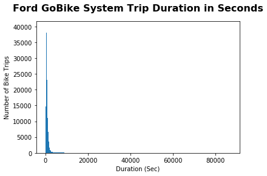

```python
# Duration of the bike rides - in SECONDS
bin_edges = np.arange(0, 87000, 60)

plt.hist(data = df_2017, x = 'duration_sec', bins = bin_edges);

plt.title("Ford GoBike System Trip Duration in Seconds", y=1.05, fontsize=16, fontweight='bold')
plt.xlabel('Duration (Sec)')
plt.ylabel('Number of Bike Trips');
```

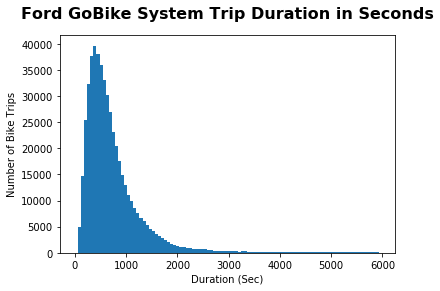

```python
# Duration of the bike rides - in SECONDS
bin_edges = np.arange(0, 6000, 60)

plt.hist(data = df_2017, x = 'duration_sec', bins = bin_edges);

plt.title("Ford GoBike System Trip Duration in Seconds", y=1.05, fontsize=16, fontweight='bold')
plt.xlabel('Duration (Sec)')
plt.ylabel('Number of Bike Trips');
```

#### Observation: Most of the trips have smaller duration in time

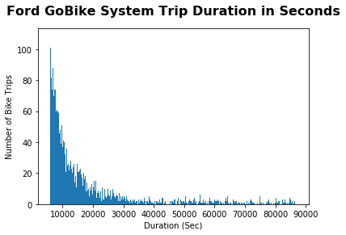

```python
# Duration of the bike rides - in SECONDS
bin_edges = np.arange(6000, 87000, 60)

plt.hist(data = df_2017, x = 'duration_sec', bins = bin_edges);

plt.title("Ford GoBike System Trip Duration in Seconds", y=1.05, fontsize=16, fontweight='bold')
plt.xlabel('Duration (Sec)')
plt.ylabel('Number of Bike Trips');
```

```python
# Statistical Analysis
df_2018['duration_sec'].describe()
```

```
count    1.863721e+06
mean     8.573026e+02
std      2.370379e+03
min      6.100000e+01
25%      3.500000e+02
50%      5.560000e+02
75%      8.720000e+02
max      8.636600e+04
Name: duration_sec, dtype: float64
```

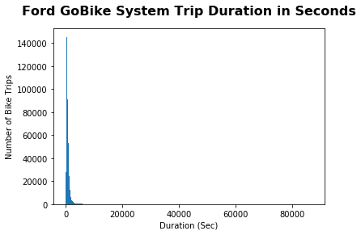

```python
# Duration of the bike rides - in SECONDS
bin_edges = np.arange(0, 87000, 60)

plt.hist(data = df_2018, x = 'duration_sec', bins = bin_edges);

plt.title("Ford GoBike System Trip Duration in Seconds", y=1.05, fontsize=16, fontweight='bold')
plt.xlabel('Duration (Sec)')
plt.ylabel('Number of Bike Trips');
```

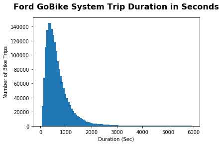

```python
# Duration of the bike rides - in SECONDS
bin_edges = np.arange(0, 6000, 60)

plt.hist(data = df_2018, x = 'duration_sec', bins = bin_edges);

plt.title("Ford GoBike System Trip Duration in Seconds", y=1.05, fontsize=16, fontweight='bold')
plt.xlabel('Duration (Sec)')
plt.ylabel('Number of Bike Trips');
```

#### Observation: Most of the trips have smaller duration in time

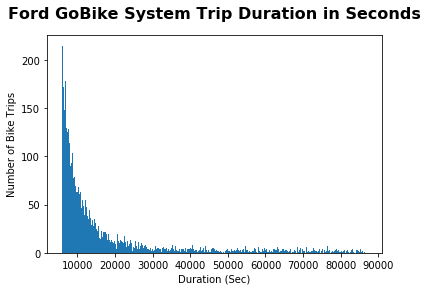

```python
# Duration of the bike rides - in SECONDS
bin_edges = np.arange(6000, 87000, 60)

plt.hist(data = df_2018, x = 'duration_sec', bins = bin_edges);

plt.title("Ford GoBike System Trip Duration in Seconds", y=1.05, fontsize=16, fontweight='bold')
plt.xlabel('Duration (Sec)')
plt.ylabel('Number of Bike Trips');
```

```python
# Statistical Analysis
df_2019['duration_sec'].describe()
```

```
count    2.506983e+06
mean     8.076483e+02
std      1.974714e+03
min      6.000000e+01
25%      3.590000e+02
50%      5.710000e+02
75%      8.870000e+02
max      9.121100e+05
Name: duration_sec, dtype: float64
```

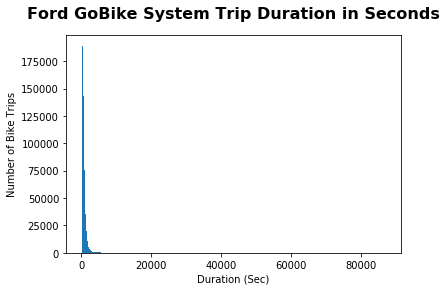

```python
# Duration of the bike rides - in SECONDS
bin_edges = np.arange(0, 87000, 60)

plt.hist(data = df_2019, x = 'duration_sec', bins = bin_edges);

plt.title("Ford GoBike System Trip Duration in Seconds", y=1.05, fontsize=16, fontweight='bold')
plt.xlabel('Duration (Sec)')
plt.ylabel('Number of Bike Trips');
```

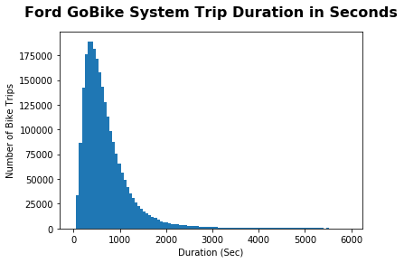

```python
# Duration of the bike rides - in SECONDS
bin_edges = np.arange(0, 6000, 60)

plt.hist(data = df_2019, x = 'duration_sec', bins = bin_edges);

plt.title("Ford GoBike System Trip Duration in Seconds", y=1.05, fontsize=16, fontweight='bold')
plt.xlabel('Duration (Sec)')
plt.ylabel('Number of Bike Trips');
```

#### Observation: Most of the trips have smaller duration in time

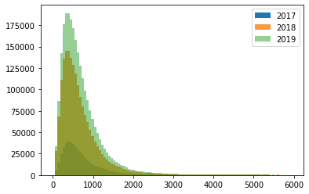

```python
# Source: https://stackoverflow.com/questions/6871201/plot-two-histograms-on-single-chart-with-matplotlib
from matplotlib import pyplot

bins = np.arange(0, 6000, 60)

pyplot.hist(df_2017['duration_sec'], bins, alpha=1, label='2017')
pyplot.hist(df_2018['duration_sec'], bins, alpha=0.8, label='2018')
pyplot.hist(df_2019['duration_sec'], bins, alpha=0.5, label='2019')
pyplot.legend(loc='upper right')
pyplot.show()
```

#### Observation: Every year the number of trips increased. So, the area under the histogram is increased every year.

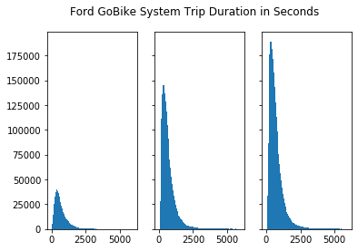

```python
# source: https://matplotlib.org/devdocs/gallery/subplots_axes_and_figures/subplots_demo.html
fig, ((ax1,ax2,ax3)) = plt.subplots(1,3,sharey=True)
fig.suptitle('Ford GoBike System Trip Duration in Seconds')
ax1.hist(df_2017['duration_sec'], bins)
ax2.hist(df_2018['duration_sec'], bins)
ax3.hist(df_2019['duration_sec'], bins)


for ax in fig.get_axes():
    ax.label_outer()
```

#### Observation: Same observation as before.

```python
# Any duplicates?
df_2017.duplicated().sum()
```

```
0
```

```python
# Any duplicates?
df_2018.duplicated().sum()
```

```
0
```

```python
# Any duplicates?
df_2019.duplicated().sum()
```

```
0
```

#### Observation: No duplicated data

```python
# What about NaN values?
df_2017.isna().sum()
```

```
duration_sec               0
start_time                 0
end_time                   0
start_station_id           0
start_station_name         0
start_station_latitude     0
start_station_longitude    0
end_station_id             0
end_station_name           0
end_station_latitude       0
end_station_longitude      0
bike_id                    0
user_type                  0
year                       0
dtype: int64
```

```python
# What about NaN values?
df_2018.isna().sum()
```

```
duration_sec                   0
start_time                     0
end_time                       0
start_station_id           11771
start_station_name         11771
start_station_latitude         0
start_station_longitude        0
end_station_id             11771
end_station_name           11771
end_station_latitude           0
end_station_longitude          0
bike_id                        0
user_type                      0
bike_share_for_all_trip        0
year                           0
dtype: int64
```

#### Observation: Some station name and id are missing

```python
# What about NaN values?
df_2019.isna().sum()
```

```
duration_sec                     0
start_time                       0
end_time                         0
start_station_id             80734
start_station_name           80133
start_station_latitude           0
start_station_longitude          0
end_station_id               82902
end_station_name             82350
end_station_latitude             0
end_station_longitude            0
bike_id                          0
user_type                        0
bike_share_for_all_trip     243259
rental_access_method       2386145
year                             0
dtype: int64
```

#### Observation: Some station info, bike sharing and rental method info missing

```python
df_2019.info()
```

```
<class 'pandas.core.frame.DataFrame'>
RangeIndex: 2506983 entries, 0 to 2506982
Data columns (total 16 columns):
duration_sec               int64
start_time                 object
end_time                   object
start_station_id           float64
start_station_name         object
start_station_latitude     float64
start_station_longitude    float64
end_station_id             float64
end_station_name           object
end_station_latitude       float64
end_station_longitude      float64
bike_id                    int64
user_type                  object
bike_share_for_all_trip    object
rental_access_method       object
year                       object
dtypes: float64(6), int64(2), object(8)
memory usage: 306.0+ MB
```

### Cleaning

```python
# Copy 2017 data
df_cleaned_2017 = df_2017.copy()
# Copy 2018 data
df_cleaned_2018 = df_2018.copy()
# Copy 2019 data
df_cleaned_2019 = df_2019.copy()
```

```python
# Changing the format to datetime for 2017 data
df_cleaned_2017.start_time = pd.to_datetime(df_cleaned_2017.start_time)
df_cleaned_2017.end_time = pd.to_datetime(df_cleaned_2017.end_time)
# Changing the format to datetime for 2018 data
df_cleaned_2018.start_time = pd.to_datetime(df_cleaned_2018.start_time)
df_cleaned_2018.end_time = pd.to_datetime(df_cleaned_2018.end_time)
# Changing the format to datetime for 2019 data
df_cleaned_2019.start_time = pd.to_datetime(df_cleaned_2019.start_time)
df_cleaned_2019.end_time = pd.to_datetime(df_cleaned_2019.end_time)
```

```python
# Changing the user_type to category format in 2017 data
df_cleaned_2017.user_type = df_cleaned_2017.user_type.astype('category')
# Changing the user_type to category format in 2018 data
df_cleaned_2018.user_type = df_cleaned_2018.user_type.astype('category')
# Changing the user_type to category format in 2019 data
df_cleaned_2019.user_type = df_cleaned_2019.user_type.astype('category')
```

```python
# Changing the bike_id, start_station_id, and end_station_id to object in 2017 data
df_cleaned_2017.bike_id = df_cleaned_2017.bike_id.astype(str)
df_cleaned_2017.start_station_id = df_cleaned_2017.start_station_id.astype(str)
df_cleaned_2017.end_station_id = df_cleaned_2017.end_station_id.astype(str)
# Changing the bike_id, start_station_id, and end_station_id to object in 2018 data
df_cleaned_2018.bike_id = df_cleaned_2018.bike_id.astype(str)
df_cleaned_2018.start_station_id = df_cleaned_2018.start_station_id.astype(str)
df_cleaned_2018.end_station_id = df_cleaned_2018.end_station_id.astype(str)
# Changing the bike_id, start_station_id, and end_station_id to object in 2019 data
df_cleaned_2019.bike_id = df_cleaned_2019.bike_id.astype(str)
df_cleaned_2019.start_station_id = df_cleaned_2019.start_station_id.astype(str)
df_cleaned_2019.end_station_id = df_cleaned_2019.end_station_id.astype(str)
```

```python
# Data Types in 2017 data
df_cleaned_2017.info()
```

```
<class 'pandas.core.frame.DataFrame'>
RangeIndex: 519700 entries, 0 to 519699
Data columns (total 14 columns):
duration_sec               519700 non-null int64
start_time                 519700 non-null datetime64[ns]
end_time                   519700 non-null datetime64[ns]
start_station_id           519700 non-null object
start_station_name         519700 non-null object
start_station_latitude     519700 non-null float64
start_station_longitude    519700 non-null float64
end_station_id             519700 non-null object
end_station_name           519700 non-null object
end_station_latitude       519700 non-null float64
end_station_longitude      519700 non-null float64
bike_id                    519700 non-null object
user_type                  519700 non-null category
year                       519700 non-null object
dtypes: category(1), datetime64[ns](2), float64(4), int64(1), object(6)
memory usage: 52.0+ MB
```

```python
# Data Types in 2018 data
df_cleaned_2018.info(null_counts=True)
```

```
<class 'pandas.core.frame.DataFrame'>
RangeIndex: 1863721 entries, 0 to 1863720
Data columns (total 15 columns):
duration_sec               1863721 non-null int64
start_time                 1863721 non-null datetime64[ns]
end_time                   1863721 non-null datetime64[ns]
start_station_id           1863721 non-null object
start_station_name         1851950 non-null object
start_station_latitude     1863721 non-null float64
start_station_longitude    1863721 non-null float64
end_station_id             1863721 non-null object
end_station_name           1851950 non-null object
end_station_latitude       1863721 non-null float64
end_station_longitude      1863721 non-null float64
bike_id                    1863721 non-null object
user_type                  1863721 non-null category
bike_share_for_all_trip    1863721 non-null object
year                       1863721 non-null object
dtypes: category(1), datetime64[ns](2), float64(4), int64(1), object(7)
memory usage: 200.8+ MB
```

```python
# Data Types in 2019 data
df_cleaned_2019.info(null_counts=True)
```

```
<class 'pandas.core.frame.DataFrame'>
RangeIndex: 2506983 entries, 0 to 2506982
Data columns (total 16 columns):
duration_sec               2506983 non-null int64
start_time                 2506983 non-null datetime64[ns]
end_time                   2506983 non-null datetime64[ns]
start_station_id           2506983 non-null object
start_station_name         2426850 non-null object
start_station_latitude     2506983 non-null float64
start_station_longitude    2506983 non-null float64
end_station_id             2506983 non-null object
end_station_name           2424633 non-null object
end_station_latitude       2506983 non-null float64
end_station_longitude      2506983 non-null float64
bike_id                    2506983 non-null object
user_type                  2506983 non-null category
bike_share_for_all_trip    2263724 non-null object
rental_access_method       120838 non-null object
year                       2506983 non-null object
dtypes: category(1), datetime64[ns](2), float64(4), int64(1), object(8)
memory usage: 289.3+ MB
```

```python
# Add column for Start time month (January - December)
df_cleaned_2017['start_time_month'] = df_cleaned_2017['start_time'].dt.strftime('%B')
df_cleaned_2018['start_time_month'] = df_cleaned_2018['start_time'].dt.strftime('%B')
df_cleaned_2019['start_time_month'] = df_cleaned_2019['start_time'].dt.strftime('%B')
```

```python
# Add column for Start time month (1-12)
df_cleaned_2017['start_time_month_num'] = df_cleaned_2017['start_time'].dt.month.astype(int)
df_cleaned_2018['start_time_month_num'] = df_cleaned_2018['start_time'].dt.month.astype(int)
df_cleaned_2019['start_time_month_num'] = df_cleaned_2019['start_time'].dt.month.astype(int)
```

```python
# Add column for Start time weekday
df_cleaned_2017['start_time_weekday'] = df_cleaned_2017['start_time'].dt.strftime('%a')
df_cleaned_2018['start_time_weekday'] = df_cleaned_2018['start_time'].dt.strftime('%a')
df_cleaned_2019['start_time_weekday'] = df_cleaned_2019['start_time'].dt.strftime('%a')
```

```python
# Add column for Start and end time hour
df_cleaned_2017['start_time_hour'] = df_cleaned_2017['start_time'].dt.hour
df_cleaned_2017['end_time_hour'] = df_cleaned_2017['end_time'].dt.hour
df_cleaned_2018['start_time_hour'] = df_cleaned_2018['start_time'].dt.hour
df_cleaned_2018['end_time_hour'] = df_cleaned_2018['end_time'].dt.hour
df_cleaned_2019['start_time_hour'] = df_cleaned_2019['start_time'].dt.hour
df_cleaned_2019['end_time_hour'] = df_cleaned_2019['end_time'].dt.hour
```

```python
df_cleaned_2017.head()
```

|  | duration_sec | start_time | end_time | start_station_id | start_station_name | start_station_latitude | start_station_longitude | end_station_id | end_station_name | end_station_latitude | end_station_longitude | bike_id | user_type | year | start_time_month | start_time_month_num | start_time_weekday | start_time_hour | end_time_hour |
| --- | --- | --- | --- | --- | --- | --- | --- | --- | --- | --- | --- | --- | --- | --- | --- | --- | --- | --- | --- |
| 0 | 80110 | 2017-12-31 16:57:39.654 | 2018-01-01 15:12:50.245 | 74 | Laguna St at Hayes St | 37.776435 | -122.426244 | 43 | San Francisco Public Library (Grove St at Hyde... | 37.778768 | -122.415929 | 96 | Customer | 2017 | December | 12 | Sun | 16 | 15 |
| 1 | 78800 | 2017-12-31 15:56:34.842 | 2018-01-01 13:49:55.617 | 284 | Yerba Buena Center for the Arts (Howard St at ... | 37.784872 | -122.400876 | 96 | Dolores St at 15th St | 37.766210 | -122.426614 | 88 | Customer | 2017 | December | 12 | Sun | 15 | 13 |
| 2 | 45768 | 2017-12-31 22:45:48.411 | 2018-01-01 11:28:36.883 | 245 | Downtown Berkeley BART | 37.870348 | -122.267764 | 245 | Downtown Berkeley BART | 37.870348 | -122.267764 | 1094 | Customer | 2017 | December | 12 | Sun | 22 | 11 |
| 3 | 62172 | 2017-12-31 17:31:10.636 | 2018-01-01 10:47:23.531 | 60 | 8th St at Ringold St | 37.774520 | -122.409449 | 5 | Powell St BART Station (Market St at 5th St) | 37.783899 | -122.408445 | 2831 | Customer | 2017 | December | 12 | Sun | 17 | 10 |
| 4 | 43603 | 2017-12-31 14:23:14.001 | 2018-01-01 02:29:57.571 | 239 | Bancroft Way at Telegraph Ave | 37.868813 | -122.258764 | 247 | Fulton St at Bancroft Way | 37.867789 | -122.265896 | 3167 | Subscriber | 2017 | December | 12 | Sun | 14 | 2 |

```python
df_cleaned_2018.head()
```

|  | duration_sec | start_time | end_time | start_station_id | start_station_name | start_station_latitude | start_station_longitude | end_station_id | end_station_name | end_station_latitude | end_station_longitude | bike_id | user_type | bike_share_for_all_trip | year | start_time_month | start_time_month_num | start_time_weekday | start_time_hour | end_time_hour |
| --- | --- | --- | --- | --- | --- | --- | --- | --- | --- | --- | --- | --- | --- | --- | --- | --- | --- | --- | --- | --- |
| 0 | 75284 | 2018-01-31 22:52:35.239 | 2018-02-01 19:47:19.824 | 120.0 | Mission Dolores Park | 37.761420 | -122.426435 | 285.0 | Webster St at O'Farrell St | 37.783521 | -122.431158 | 2765 | Subscriber | No | 2018 | January | 1 | Wed | 22 | 19 |
| 1 | 85422 | 2018-01-31 16:13:34.351 | 2018-02-01 15:57:17.310 | 15.0 | San Francisco Ferry Building (Harry Bridges Pl... | 37.795392 | -122.394203 | 15.0 | San Francisco Ferry Building (Harry Bridges Pl... | 37.795392 | -122.394203 | 2815 | Customer | No | 2018 | January | 1 | Wed | 16 | 15 |
| 2 | 71576 | 2018-01-31 14:23:55.889 | 2018-02-01 10:16:52.116 | 304.0 | Jackson St at 5th St | 37.348759 | -121.894798 | 296.0 | 5th St at Virginia St | 37.325998 | -121.877120 | 3039 | Customer | No | 2018 | January | 1 | Wed | 14 | 10 |
| 3 | 61076 | 2018-01-31 14:53:23.562 | 2018-02-01 07:51:20.500 | 75.0 | Market St at Franklin St | 37.773793 | -122.421239 | 47.0 | 4th St at Harrison St | 37.780955 | -122.399749 | 321 | Customer | No | 2018 | January | 1 | Wed | 14 | 7 |
| 4 | 39966 | 2018-01-31 19:52:24.667 | 2018-02-01 06:58:31.053 | 74.0 | Laguna St at Hayes St | 37.776435 | -122.426244 | 19.0 | Post St at Kearny St | 37.788975 | -122.403452 | 617 | Subscriber | No | 2018 | January | 1 | Wed | 19 | 6 |

```python
df_cleaned_2019.head()
```

|  | duration_sec | start_time | end_time | start_station_id | start_station_name | start_station_latitude | start_station_longitude | end_station_id | end_station_name | end_station_latitude | ... | bike_id | user_type | bike_share_for_all_trip | rental_access_method | year | start_time_month | start_time_month_num | start_time_weekday | start_time_hour | end_time_hour |
| --- | --- | --- | --- | --- | --- | --- | --- | --- | --- | --- | --- | --- | --- | --- | --- | --- | --- | --- | --- | --- | --- |
| 0 | 80825 | 2019-01-31 17:57:44.613 | 2019-02-01 16:24:49.864 | 229.0 | Foothill Blvd at 42nd Ave | 37.775745 | -122.213037 | 196.0 | Grand Ave at Perkins St | 37.808894 | ... | 4861 | Subscriber | No | NaN | 2019 | January | 1 | Thu | 17 | 16 |
| 1 | 65900 | 2019-01-31 20:58:33.886 | 2019-02-01 15:16:54.173 | 4.0 | Cyril Magnin St at Ellis St | 37.785881 | -122.408915 | 134.0 | Valencia St at 24th St | 37.752428 | ... | 5506 | Subscriber | No | NaN | 2019 | January | 1 | Thu | 20 | 15 |
| 2 | 62633 | 2019-01-31 18:06:52.924 | 2019-02-01 11:30:46.530 | 245.0 | Downtown Berkeley BART | 37.870139 | -122.268422 | 157.0 | 65th St at Hollis St | 37.846784 | ... | 2717 | Customer | No | NaN | 2019 | January | 1 | Thu | 18 | 11 |
| 3 | 44680 | 2019-01-31 19:46:09.719 | 2019-02-01 08:10:50.318 | 85.0 | Church St at Duboce Ave | 37.770083 | -122.429156 | 53.0 | Grove St at Divisadero | 37.775946 | ... | 4557 | Customer | No | NaN | 2019 | January | 1 | Thu | 19 | 8 |
| 4 | 60709 | 2019-01-31 14:19:01.541 | 2019-02-01 07:10:51.065 | 16.0 | Steuart St at Market St | 37.794130 | -122.394430 | 28.0 | The Embarcadero at Bryant St | 37.787168 | ... | 2100 | Customer | No | NaN | 2019 | January | 1 | Thu | 14 | 7 |

5 rows × 21 columns

```python
# Calculate distance between Lat/long points
# Source: https://www.movable-type.co.uk/scripts/latlong.html
"""
Haversine
formula:	a = sin²(Δφ/2) + cos φ1 ⋅ cos φ2 ⋅ sin²(Δλ/2)
c = 2 ⋅ atan2( √a, √(1−a) )
d = R ⋅ c
where	φ is latitude, λ is longitude, R is earth’s radius (mean radius = 6,371km);
note that angles need to be in radians to pass to trig functions!
"""
import math
from math import radians, sin, cos, acos

def distance(origin, destination):

    lat1, long1 = origin
    lat2, long2 = destination
    radius = 6371
    # this is in kilometers - will convert to US units of miles after

    dlat = math.radians(lat2 - lat1)
    dlong = math.radians(long2 - long1)

    a = (math.sin(dlat / 2) * math.sin(dlat / 2) + math.cos(math.radians(lat1)) * math.cos(math.radians(lat2)) * math.sin(dlong / 2) * math.sin(dlong / 2))
    c = 2 * math.atan2(math.sqrt(a), math.sqrt(1 - a))
    d = radius * c

    return d
```

```python
# Add column for Distance in km
df_cleaned_2017['distance_km'] = df_cleaned_2017.apply(lambda x: distance((x['start_station_latitude'], x['start_station_longitude']), (x['end_station_latitude'], x['end_station_longitude'])), axis=1)
df_cleaned_2018['distance_km'] = df_cleaned_2018.apply(lambda x: distance((x['start_station_latitude'], x['start_station_longitude']), (x['end_station_latitude'], x['end_station_longitude'])), axis=1)
df_cleaned_2019['distance_km'] = df_cleaned_2019.apply(lambda x: distance((x['start_station_latitude'], x['start_station_longitude']), (x['end_station_latitude'], x['end_station_longitude'])), axis=1)
```

```python
df_cleaned_2017.head()
```

|  | duration_sec | start_time | end_time | start_station_id | start_station_name | start_station_latitude | start_station_longitude | end_station_id | end_station_name | end_station_latitude | end_station_longitude | bike_id | user_type | year | start_time_month | start_time_month_num | start_time_weekday | start_time_hour | end_time_hour | distance_km |
| --- | --- | --- | --- | --- | --- | --- | --- | --- | --- | --- | --- | --- | --- | --- | --- | --- | --- | --- | --- | --- |
| 0 | 80110 | 2017-12-31 16:57:39.654 | 2018-01-01 15:12:50.245 | 74 | Laguna St at Hayes St | 37.776435 | -122.426244 | 43 | San Francisco Public Library (Grove St at Hyde... | 37.778768 | -122.415929 | 96 | Customer | 2017 | December | 12 | Sun | 16 | 15 | 0.942931 |
| 1 | 78800 | 2017-12-31 15:56:34.842 | 2018-01-01 13:49:55.617 | 284 | Yerba Buena Center for the Arts (Howard St at ... | 37.784872 | -122.400876 | 96 | Dolores St at 15th St | 37.766210 | -122.426614 | 88 | Customer | 2017 | December | 12 | Sun | 15 | 13 | 3.069727 |
| 2 | 45768 | 2017-12-31 22:45:48.411 | 2018-01-01 11:28:36.883 | 245 | Downtown Berkeley BART | 37.870348 | -122.267764 | 245 | Downtown Berkeley BART | 37.870348 | -122.267764 | 1094 | Customer | 2017 | December | 12 | Sun | 22 | 11 | 0.000000 |
| 3 | 62172 | 2017-12-31 17:31:10.636 | 2018-01-01 10:47:23.531 | 60 | 8th St at Ringold St | 37.774520 | -122.409449 | 5 | Powell St BART Station (Market St at 5th St) | 37.783899 | -122.408445 | 2831 | Customer | 2017 | December | 12 | Sun | 17 | 10 | 1.046622 |
| 4 | 43603 | 2017-12-31 14:23:14.001 | 2018-01-01 02:29:57.571 | 239 | Bancroft Way at Telegraph Ave | 37.868813 | -122.258764 | 247 | Fulton St at Bancroft Way | 37.867789 | -122.265896 | 3167 | Subscriber | 2017 | December | 12 | Sun | 14 | 2 | 0.636339 |

```python
df_cleaned_2018.head()
```

|  | duration_sec | start_time | end_time | start_station_id | start_station_name | start_station_latitude | start_station_longitude | end_station_id | end_station_name | end_station_latitude | ... | bike_id | user_type | bike_share_for_all_trip | year | start_time_month | start_time_month_num | start_time_weekday | start_time_hour | end_time_hour | distance_km |
| --- | --- | --- | --- | --- | --- | --- | --- | --- | --- | --- | --- | --- | --- | --- | --- | --- | --- | --- | --- | --- | --- |
| 0 | 75284 | 2018-01-31 22:52:35.239 | 2018-02-01 19:47:19.824 | 120.0 | Mission Dolores Park | 37.761420 | -122.426435 | 285.0 | Webster St at O'Farrell St | 37.783521 | ... | 2765 | Subscriber | No | 2018 | January | 1 | Wed | 22 | 19 | 2.492254 |
| 1 | 85422 | 2018-01-31 16:13:34.351 | 2018-02-01 15:57:17.310 | 15.0 | San Francisco Ferry Building (Harry Bridges Pl... | 37.795392 | -122.394203 | 15.0 | San Francisco Ferry Building (Harry Bridges Pl... | 37.795392 | ... | 2815 | Customer | No | 2018 | January | 1 | Wed | 16 | 15 | 0.000000 |
| 2 | 71576 | 2018-01-31 14:23:55.889 | 2018-02-01 10:16:52.116 | 304.0 | Jackson St at 5th St | 37.348759 | -121.894798 | 296.0 | 5th St at Virginia St | 37.325998 | ... | 3039 | Customer | No | 2018 | January | 1 | Wed | 14 | 10 | 2.974502 |
| 3 | 61076 | 2018-01-31 14:53:23.562 | 2018-02-01 07:51:20.500 | 75.0 | Market St at Franklin St | 37.773793 | -122.421239 | 47.0 | 4th St at Harrison St | 37.780955 | ... | 321 | Customer | No | 2018 | January | 1 | Wed | 14 | 7 | 2.049710 |
| 4 | 39966 | 2018-01-31 19:52:24.667 | 2018-02-01 06:58:31.053 | 74.0 | Laguna St at Hayes St | 37.776435 | -122.426244 | 19.0 | Post St at Kearny St | 37.788975 | ... | 617 | Subscriber | No | 2018 | January | 1 | Wed | 19 | 6 | 2.440571 |

5 rows × 21 columns

```python
df_cleaned_2019.head()
```

|  | duration_sec | start_time | end_time | start_station_id | start_station_name | start_station_latitude | start_station_longitude | end_station_id | end_station_name | end_station_latitude | ... | user_type | bike_share_for_all_trip | rental_access_method | year | start_time_month | start_time_month_num | start_time_weekday | start_time_hour | end_time_hour | distance_km |
| --- | --- | --- | --- | --- | --- | --- | --- | --- | --- | --- | --- | --- | --- | --- | --- | --- | --- | --- | --- | --- | --- |
| 0 | 80825 | 2019-01-31 17:57:44.613 | 2019-02-01 16:24:49.864 | 229.0 | Foothill Blvd at 42nd Ave | 37.775745 | -122.213037 | 196.0 | Grand Ave at Perkins St | 37.808894 | ... | Subscriber | No | NaN | 2019 | January | 1 | Thu | 17 | 16 | 5.305199 |
| 1 | 65900 | 2019-01-31 20:58:33.886 | 2019-02-01 15:16:54.173 | 4.0 | Cyril Magnin St at Ellis St | 37.785881 | -122.408915 | 134.0 | Valencia St at 24th St | 37.752428 | ... | Subscriber | No | NaN | 2019 | January | 1 | Thu | 20 | 15 | 3.859628 |
| 2 | 62633 | 2019-01-31 18:06:52.924 | 2019-02-01 11:30:46.530 | 245.0 | Downtown Berkeley BART | 37.870139 | -122.268422 | 157.0 | 65th St at Hollis St | 37.846784 | ... | Customer | No | NaN | 2019 | January | 1 | Thu | 18 | 11 | 3.287098 |
| 3 | 44680 | 2019-01-31 19:46:09.719 | 2019-02-01 08:10:50.318 | 85.0 | Church St at Duboce Ave | 37.770083 | -122.429156 | 53.0 | Grove St at Divisadero | 37.775946 | ... | Customer | No | NaN | 2019 | January | 1 | Thu | 19 | 8 | 0.999632 |
| 4 | 60709 | 2019-01-31 14:19:01.541 | 2019-02-01 07:10:51.065 | 16.0 | Steuart St at Market St | 37.794130 | -122.394430 | 28.0 | The Embarcadero at Bryant St | 37.787168 | ... | Customer | No | NaN | 2019 | January | 1 | Thu | 14 | 7 | 0.953355 |

5 rows × 22 columns

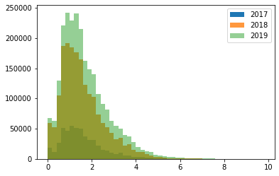

```python
# Source: https://stackoverflow.com/questions/6871201/plot-two-histograms-on-single-chart-with-matplotlib
from matplotlib import pyplot

bins = np.arange(0, 10, 0.2)

pyplot.hist(df_cleaned_2017['distance_km'], bins, alpha=1, label='2017')
pyplot.hist(df_cleaned_2018['distance_km'], bins, alpha=0.8, label='2018')
pyplot.hist(df_cleaned_2019['distance_km'], bins, alpha=0.5, label='2019')
pyplot.legend(loc='upper right')
pyplot.show()
```

#### Observation: Most of the trips have short distance. Number of trips have increased each year.

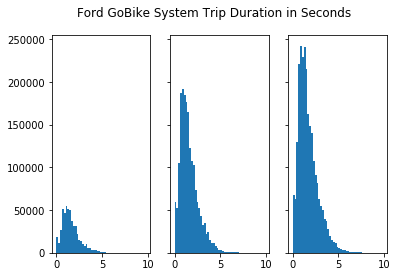

```python
# source: https://matplotlib.org/devdocs/gallery/subplots_axes_and_figures/subplots_demo.html
fig, ((ax1,ax2,ax3)) = plt.subplots(1,3,sharey=True)
fig.suptitle('Ford GoBike System Trip Duration in Seconds')
ax1.hist(df_cleaned_2017['distance_km'], bins)
ax2.hist(df_cleaned_2018['distance_km'], bins)
ax3.hist(df_cleaned_2019['distance_km'], bins)


for ax in fig.get_axes():
    ax.label_outer()
```

#### Observation: Same observation as before.

# Saving Data

```python
df_cleaned_2017.to_csv('df_cleaned_2017.csv',index=False)
df_cleaned_2018.to_csv('df_cleaned_2018.csv',index=False)
df_cleaned_2019.to_csv('df_cleaned_2019.csv',index=False)
```

```python
df_cleaned_2019.shape
```

```
(2506983, 22)
```

### Summary

This notebook uses data collected from June 2017 through December 2019. Because of memory limitation, data are kept in three different files corresponding to three years 2017, 2018 and 2019.

- 2017 data file has 5,19,700 trips infomation.
- 2018 data file has 18,63,721 trips infomation.
- 2019 data file has 25,06,983 trip infomation.

The column header descriptions are as follows:

- Trip Duration (seconds)
- Start Time and Date
- End Time and Date
- Start Station ID
- Start Station Name
- Start Station Latitude
- Start Station Longitude
- End Station ID
- End Station Name
- End Station Latitude
- End Station Longitude
- Bike ID
- User Type (Subscriber or Customer – “Subscriber” = Member or “Customer” = Casual)
- bike_share_for_all_trip (present 2018 and 2019 data)
- rental_access_method (present in 2019 data)